# Effects of Rising Temperatures on Urban Communities in Los Angeles, California

Christina Marsh

Wednesday, October 14th

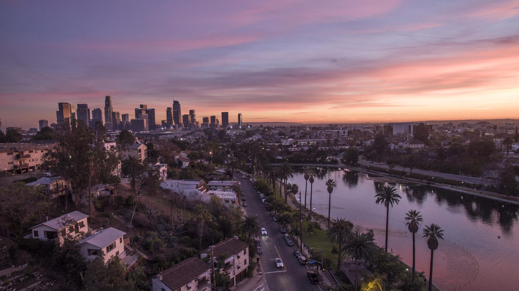

Fig. 1 Los Angeles Skyline

## The Climate of Los Angeles

Each year, more Americans die as a result of heat than all other natural disasters combined (“Extreme Heat”, 2020). The climate of Los Angeles is a mild-to-hot and mostly dry climate for the year round. The climate is described as a Mediterranean climate, which is a type of dry subtropical climate. Climate change is primarily responsible for the warming trend seen Los Angeles and across the globe, but it’s not the only force at work (Montanñez, 2017).

## Complications of Heat

Unlike many other Californians, and Americans in general, some Angelenos are also contending with an additional layer of heat intensification caused by what’s known as the “urban heat island effect.” It means that cities — with their asphalt streets, dark roofs, sparse vegetation and traffic congested roads — are almost always a few degrees warmer than the more rural areas that surround them (Netburn, 2017). And the L.A. neighborhoods that have the least tree canopy are at greatest risk for heat-related hospitalizations and deaths (Montañez, 2017). I will analyze temperature data of avarage minimum temperature and average maximum temperature to see if there is a significant increase according to the Downtown Los Angeles weather station. I will provide an idea of the rate of warming so that if the temperature increase is significant here, we can assume that the urban heat island effect makes it even worse for those living in low income and densly populated parts of the city.

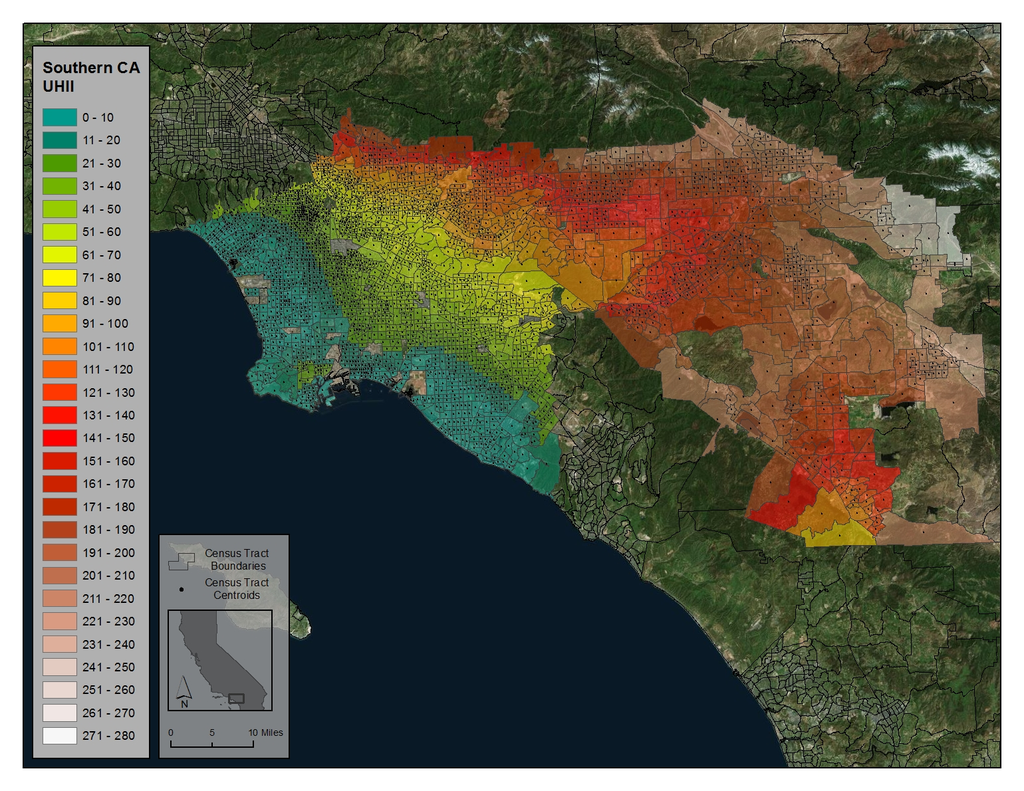

Fig.2 Urban heat island temperatures in the greater Los Angeles area divided by Census Tract Boundraies. The Urban Heat Index is calculated as a temperature differential over time between an urban census tract and nearby upwind rural reference points. The index is reported in degree-hours per day on a Celcius scale and is demonstrated through the color shifts on the map. Colors approaching white indicate higher temperatures.The weather station referenced is located in a light green 51-60 UHII category. Image via CalEPA 2020

The study *Characterization of Urban Heat and Exacerbation: Development of a Heat Island Index* discusses concerns that heat events may become more common with climate change and exacerbate urban populations particularly the elderly. The study helped determine that urban heat is exacerbated during warmer weather and that, in turn, can worsen the health impacts of heat events presently and in the future, for which it is expected that both the frequency and duration of heat waves will increase. This research can help public health agencies in quantify heat stress and make clear where developing mitigation plans or allocating various resources would be most effective (Taha 18, 2017).

## Reading Air Temperature Data

To analyze the data, I read and interpreted the p and adjusted $R^2$ values to ultimately test this null hypothesis: that the slope is 0. The significance of the p-value and $R^2$ value depends on how high the values are. In an effort to further the scope of my study, I accessed multiple peer review journals for information about heat mitigation and impact studies.

## Average Minimum Temperature Data

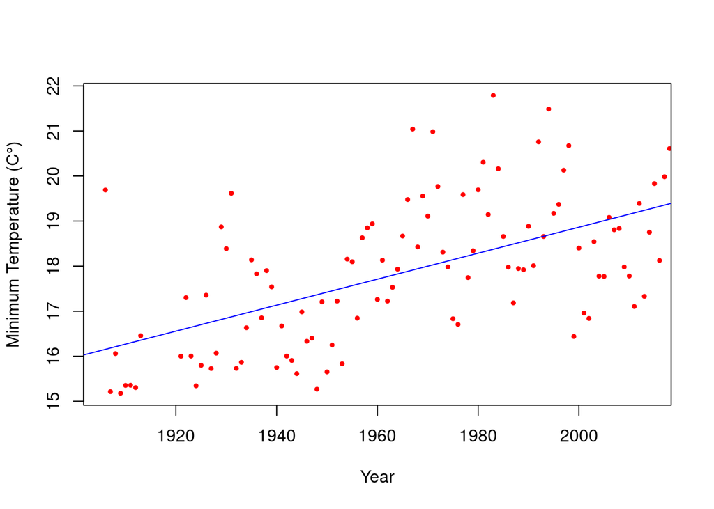

Fig. 3 August Minimum Temperature Plot

The p-value for this model was 1.762e-07 (which is much less than 0.05) and r-squared value of .228, meaning the trend is statistically significant, and that temperatures are in fact increasing in Los Angeles. Therefore we reject the null hypothesis that the slope is 0. The overall trend of Minimum Temperature data is significantly positive meaning the trend is statistically significant, and that temperatures are in fact increasing in Los Angeles. We can a 3.11 C° increase in average minimum temperature over time for the month of August.

## Average Maximum Temperature Data

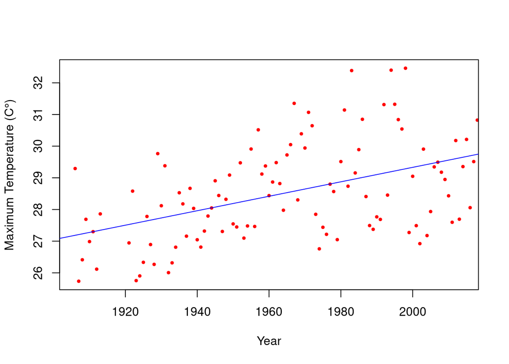

Fig. 4 August Maximum Temperature Plot

## Community Action and Mitigation

The data concludes that temperatures are rising. It can thus be inferred that the rising temperature will exxacerabte locations in the Los Angeles area that are more densly populated and urban, making health outcomes and quality of life worse for many marganilized residence like the elderly. This data can help strengthen existing arguments around the idea that local activists and politicians have raised around the need for better heat mitigation to help the Los Angeles Metropolitan area. Eric Garcetti, Mayor of Los Angeles, has pointed for the need to take actions to fight against climate change through appropriate mitigation efforts (Netburn, 2017). *Potential overall heat exposure reduction associated with implementation of heat mitigation strategies in Los Angele* gives insight into heat mitigation that compares a variety of strategies. The study explores both the benefits and flaws of analyzing the effects of increasing vegetative cooling the urban environment and its adverse consequences due to the associated potential increase in dew point temperatures (Sailor 5, 2020). Additional research must be done to account for monetary costs to implementation. The study also ignores a key factor of accessibility and general feasibility. Tree People, a local non profit is working to help reduce the build-up of heat from exposed asphalt and buildings, and decrease energy demand by planting trees, an strong example of a community led mitigation effort that has been proven to help this effort. In tandem with advocacy groups like Climate Resolve, a local youth lead organization fighting to increase urban cooling, community efforts have been fundamental in creating a more responsive and accesible movement.

## Conclusion: A Call to Action

When analyzed together, several weather stations throughout Los Angeles can create an more comprhensive picture of the temperature shifts present then what will be apparent from looking at just one station alone. More exploration needs to be done in determining how widespread these problems are and if the urban heat island phenomenon extends to more major cities (Taha 15, 2017). More research needs to be done to access cost effective and timely ways in which communities can implement mitigation techniques and if mitigation efforts are the best method of fitting urban heat. By increasing community engagement with this issue, will increase the ability for meaningful work to be done. The community voice is very important in this as conversation advocating for better data collection, stronger climate mitigation policy, and an increase in accesible climate education are all tools that can be used to improve upon existing efforts to minimize climate impacts. With greater support and participation, organizations like Tree People and the Climate Resolve can grow and thus gain the resources to more effectivly carry out their goals.

## References

“Extreme Heat.” Centers for Disease Control and Prevention, Centers for Disease Control and Prevention, 25 Sept. 2020, www.cdc.gov/disasters/extremeheat/index.html.

Kalkstein, A.J., Kalkstein, L.S., Vanos, J.K. et al. Heat/mortality sensitivities in Los Angeles during winter: a unique phenomenon in the United States. Environ Health 17, 45 (2018). https://doi.org/10.1186/s12940-018-0389-7

Montañez, C., & Fink, D. (2017, February 15). Opinion: L.A. is already trying to reduce the effect of its ‘urban heat island’. Retrieved September 27, 2020, from https://www.latimes.com/opinion/readersreact/la-ol-le-heat-island-los-angeles-20170215-story.html

Netburn, D. (2017, February 9). L.A.’s mayor wants to lower the city’s temperature. These scientists are figuring out how to do it. Retrieved September 27, 2020, from https://www.latimes.com/projects/la-sci-cooling-los-angeles/

Sailor, D.J., Anand, J. Potential overall heat exposure reduction associated with implementation of heat mitigation strategies in Los Angeles. Int J Biometeorol (2020). https://doi.org/10.1007/s00484-020-01954-5 Southern California Public Radio. (2017, May 31). LA area has highest urban heat island effect in California. Retrieved September 27, 2020, from https://www.scpr.org/news/2015/09/21/54511/la-area-has-highest-urban-heat-island-effect-in-ca/

Taha, H. Characterization of Urban Heat and Exacerbation: Development of a Heat Island Index for California. Climate 2017, 5, 59. https://www.mdpi.com/2225-1154/5/3/59#

https://www.epa.gov/climate-indicators/climate-change-indicators-us-and-global-temperature